# Project_1_mussel

Me

24/10/2020

## How old is mussel?

In this work presented statistical analysis of size and age of the mussels.

### Work data

Save work directory to ‘My_way’.

```r
My_way <- "/home/stas/git/BI_Stat_2020/project_1_mussels//data/"
```

Collect all data to one table using import Data function.

```r
df <- importData(My_way)
```

### EDA

1. Rename ‘Sex..1…male..2…female..3…uvenil’
2. Change type ‘Sex..1…male..2…female..3…uvenil’, ‘Rings’ и ‘Length’

```
## 'data.frame':    4177 obs. of  9 variables:
##  $ Rings                                 : chr  "18" "14" "8" "12" ...
##  $ Sex..1...male..2...female..3...uvenil.: chr  "2" "3" "1" "1" ...
##  $ Length                                : chr  "0.575" "0.385" "0.475" "0.665" ...
##  $ Diameter                              : num  0.45 0.305 0.37 0.525 0.12 0.16 0.565 0.43 0.175 0.3 ...
##  $ Height                                : num  0.17 0.095 0.125 0.18 0.075 0.05 0.2 0.15 0.055 0.115 ...
##  $ Whole_weight                          : num  1.048 0.252 0.649 1.429 0.117 ...
##  $ Shucked_weight                        : num  0.3775 0.0915 0.347 0.6715 0.0455 ...
##  $ Viscera_weight                        : num  0.171 0.055 0.136 0.29 0.029 ...
##  $ Shell_weight                          : num  0.385 0.09 0.142 0.4 0.0345 0.015 0.494 0.221 0.018 0.0935 ...
```

```
## 'data.frame':    4177 obs. of  9 variables:
##  $ Rings         : num  18 14 8 12 4 4 12 8 6 8 ...
##  $ Sex           : Factor w/ 3 levels "Male","Female",..: 2 3 1 1 3 3 1 2 3 2 ...
##  $ Length        : num  0.575 0.385 0.475 0.665 0.28 0.22 0.72 0.55 0.235 0.4 ...
##  $ Diameter      : num  0.45 0.305 0.37 0.525 0.12 0.16 0.565 0.43 0.175 0.3 ...
##  $ Height        : num  0.17 0.095 0.125 0.18 0.075 0.05 0.2 0.15 0.055 0.115 ...
##  $ Whole_weight  : num  1.048 0.252 0.649 1.429 0.117 ...
##  $ Shucked_weight: num  0.3775 0.0915 0.347 0.6715 0.0455 ...
##  $ Viscera_weight: num  0.171 0.055 0.136 0.29 0.029 ...
##  $ Shell_weight  : num  0.385 0.09 0.142 0.4 0.0345 0.015 0.494 0.221 0.018 0.0935 ...
```

Our data contains 25 of NA.

I deleted all samples with NA because there are not many of them. It is the most simple way, but not the best.

Check outliers for each sexes.

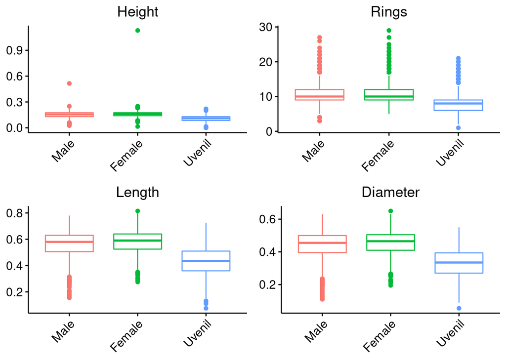

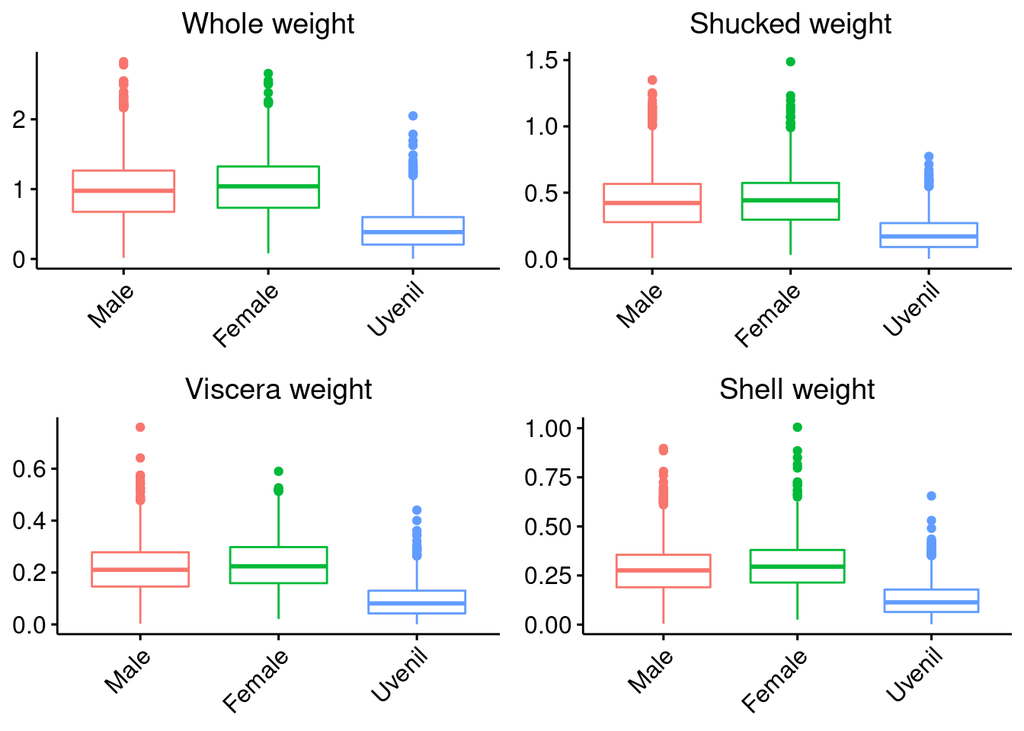

‘Height’ has two outliers also confirmed by Grubbs’s test. They will be deleted from analysis.

```
##
##  Grubbs test for one outlier
##
## data:  Mussel_data$Height
## G = 23.675, U = 0.865, p-value <2e-16
## alternative hypothesis: highest value 1.13 is an outlier
```

```
##
##  Grubbs test for one outlier
##
## data:  Mussel_data$Height
## G = 9.655, U = 0.978, p-value <2e-16
## alternative hypothesis: highest value 0.515 is an outlier
```

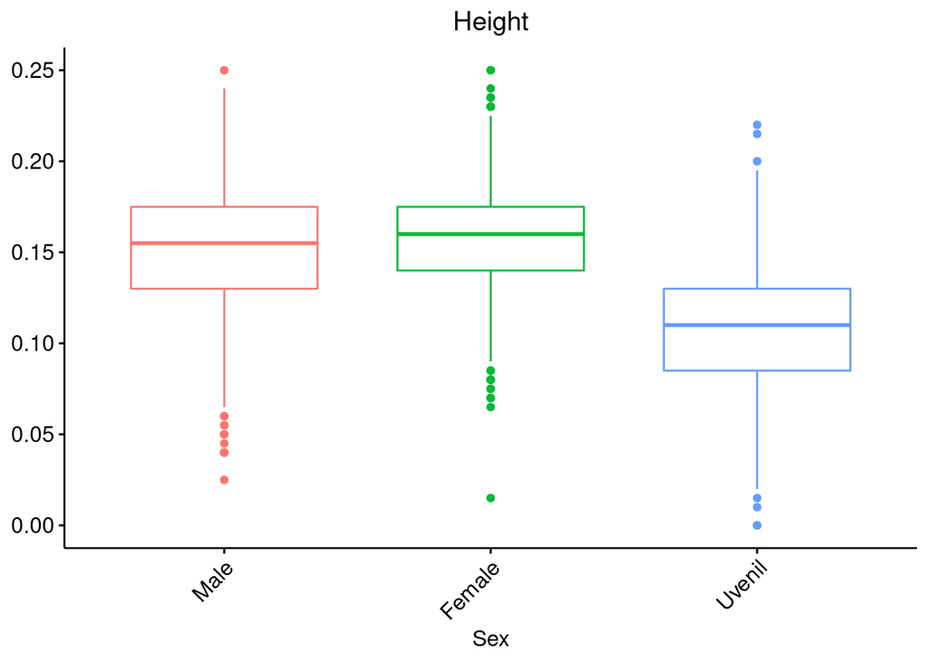

Check interconnection between variables.

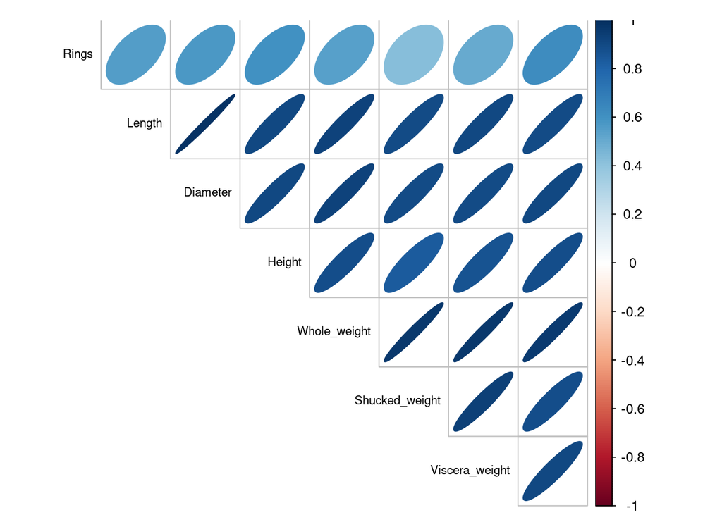

### EDA results

1. Strong correlation between length and diameter
2. Strong correlation between weight and diameter
3. Juveniles are smaller than adults

### Main

Mean and sd for mussels from different sex

| Sex | Mean | Standart_deviation |
| --- | --- | --- |
| Male | 0.56149 | 0.10255 |
| Female | 0.57954 | 0.08621 |
| Uvenil | 0.42796 | 0.10875 |

Calculate percent of mussels with Height less than 0.165

75.82% of mussels have Height less than 0.165

Length value which greater than length of 92% of other mussels: 0.67

### Create Length_z_scores

| Rings | Sex | Length | Diameter | Height | Whole_weight | Shucked_weight | Viscera_weight | Shell_weight | Lenght_z_scores |
| --- | --- | --- | --- | --- | --- | --- | --- | --- | --- |
| 18 | Female | 0.575 | 0.450 | 0.170 | 1.0475 | 0.3775 | 0.1705 | 0.3850 | 0.42308 |
| 14 | Uvenil | 0.385 | 0.305 | 0.095 | 0.2520 | 0.0915 | 0.0550 | 0.0900 | -1.15950 |
| 8 | Male | 0.475 | 0.370 | 0.125 | 0.6490 | 0.3470 | 0.1360 | 0.1420 | -0.40986 |
| 12 | Male | 0.665 | 0.525 | 0.180 | 1.4290 | 0.6715 | 0.2900 | 0.4000 | 1.17273 |
| 4 | Uvenil | 0.280 | 0.120 | 0.075 | 0.1170 | 0.0455 | 0.0290 | 0.0345 | -2.03409 |

### Statistic tests

Compare mussels with 5 and 15 rings

```
##
##  Welch Two Sample t-test
##
## data:  diam_15 and diam_5
## t = 33.5, df = 196, p-value <2e-16
## alternative hypothesis: true difference in means is greater than 0
## 95 percent confidence interval:
##  0.23316     Inf
## sample estimates:
## mean of x mean of y
##   0.45626   0.21101
```

Mussels with 15 rings have greater diameter than mussels with 5 rings (t = 33.51651, df = 196, p-value < 2e-16)

### Diametr and Whole_weight

```
##
##  Pearson's product-moment correlation
##
## data:  Mussel_data$Diameter and Mussel_data$Whole_weight
## t = 158, df = 4148, p-value <2e-16
## alternative hypothesis: true correlation is not equal to 0
## 95 percent confidence interval:
##  0.92126 0.92997
## sample estimates:
##     cor
## 0.92573
```

Diameter and Whole_weight are correlated (t = 157.65733, df = 4148 , p-palue < 2e-16)